## Loading and preprocessing the data

The `activity.csv` file was loaded using `read.csv` function. The option of `header` was set to `TRUE` by default.

```r
setwd("C:/R_coursera/RepData_PeerAssessment1")
activity <- read.csv("./activity.csv")
```

## What is mean total number of steps taken per day?

A function of `sumnona` is constructed to calculate the sum of steps for each day ignoring the `NA`s in the data. The result is saved in `sumofsteps`.

```r
sumnona <- function(x) {sum(x, na.rm = TRUE)}
sumofsteps <- tapply(activity$steps, activity$date, sumnona)
sumofsteps
```

```
## 2012-10-01 2012-10-02 2012-10-03 2012-10-04 2012-10-05 2012-10-06
##          0        126      11352      12116      13294      15420
## 2012-10-07 2012-10-08 2012-10-09 2012-10-10 2012-10-11 2012-10-12
##      11015          0      12811       9900      10304      17382
## 2012-10-13 2012-10-14 2012-10-15 2012-10-16 2012-10-17 2012-10-18
##      12426      15098      10139      15084      13452      10056
## 2012-10-19 2012-10-20 2012-10-21 2012-10-22 2012-10-23 2012-10-24
##      11829      10395       8821      13460       8918       8355
## 2012-10-25 2012-10-26 2012-10-27 2012-10-28 2012-10-29 2012-10-30
##       2492       6778      10119      11458       5018       9819
## 2012-10-31 2012-11-01 2012-11-02 2012-11-03 2012-11-04 2012-11-05
##      15414          0      10600      10571          0      10439
## 2012-11-06 2012-11-07 2012-11-08 2012-11-09 2012-11-10 2012-11-11
##       8334      12883       3219          0          0      12608
## 2012-11-12 2012-11-13 2012-11-14 2012-11-15 2012-11-16 2012-11-17
##      10765       7336          0         41       5441      14339
## 2012-11-18 2012-11-19 2012-11-20 2012-11-21 2012-11-22 2012-11-23
##      15110       8841       4472      12787      20427      21194
## 2012-11-24 2012-11-25 2012-11-26 2012-11-27 2012-11-28 2012-11-29
##      14478      11834      11162      13646      10183       7047
## 2012-11-30
##          0
```

The histogram is constructed below using `breaks = 10`.

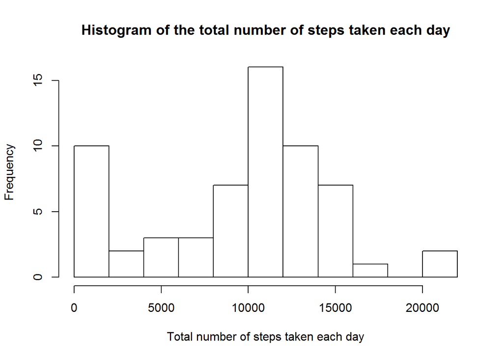

```r
hist(sumofsteps, breaks = 10, main = "Histogram of the total number of steps taken each day", xlab = "Total number of steps taken each day")
```

The mean of the total number of steps taken per day is:

```r
mean(sumofsteps)
```

```
## [1] 9354.23
```

The median of the total number of steps taken per day is:

```r
median(sumofsteps)
```

```
## [1] 10395
```

## What is the average daily activity pattern?

First, we need to make the `inteval` a factor variable.

```r
activity$interval <- factor(activity$interval)
```

Then we need to calculate the average of steps taken for each interval, averaged across all days. The result is saved in `meanofsteps`.

```r
meannona <- function(x) {mean(x, na.rm = TRUE)}
meanofsteps <- tapply(activity$steps, activity$interval, meannona)
```

To construct the a time series plot:

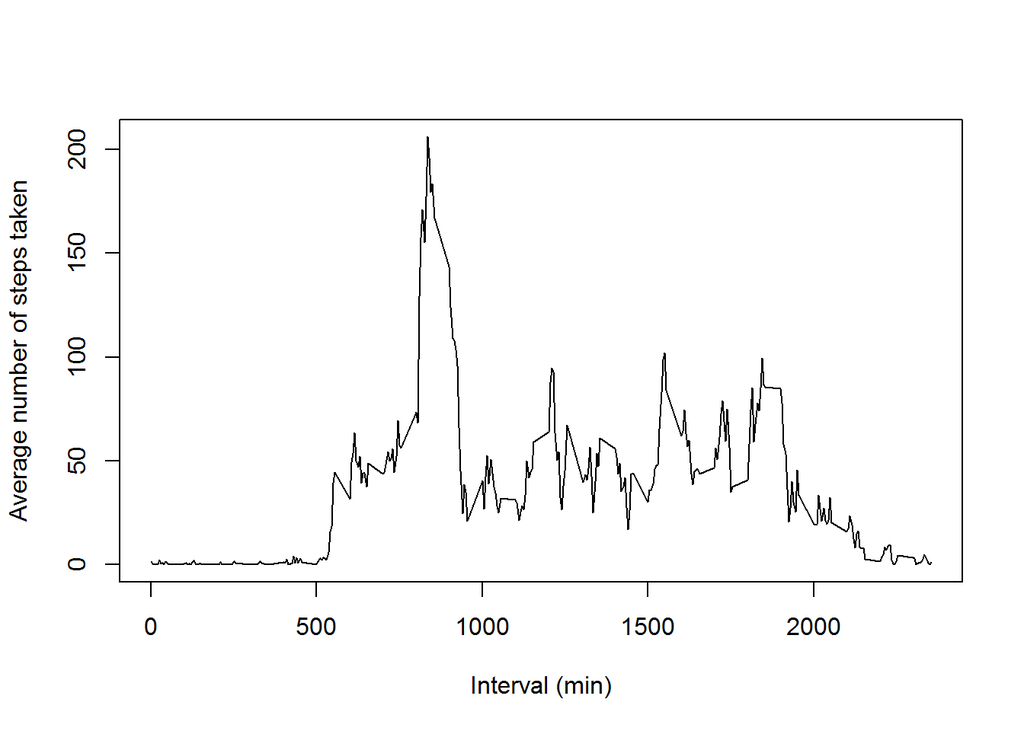

```r
plot(unlist(dimnames(meanofsteps)), meanofsteps, type = "l", xlab = "Interval (min)", ylab = "Average number of steps taken")
```

The maximum average number of steps occurs at:

```r
names(which.max(meanofsteps))
```

```
## [1] "835"
```

## Imputing missing values

The total number of missing values in the dataset:

```r
sum(is.na(activity$steps))
```

```
## [1] 2304
```

I chose to use the mean for that 5-minute interval to fill in all the `NA`s. First, copy all the data into a new dataset `newac`.

```r
newac <- activity
```

Then fill in all the `NA`s using the mean for that 5-minute interval.

```r
for (i in 1:nrow(newac)) {
      if (is.na(newac$steps[i])) {
            inte <- newac$interval[i]
            newval <- unname(meanofsteps[names(meanofsteps) == inte])
            newac$steps[i] <- newval
      }
}
```

Calulate the total number of steps taken each day. The results is save in `newsum`.

```r
newsum <- tapply(newac$steps, newac$date, sum)
newsum
```

```
## 2012-10-01 2012-10-02 2012-10-03 2012-10-04 2012-10-05 2012-10-06
##   10766.19     126.00   11352.00   12116.00   13294.00   15420.00
## 2012-10-07 2012-10-08 2012-10-09 2012-10-10 2012-10-11 2012-10-12
##   11015.00   10766.19   12811.00    9900.00   10304.00   17382.00
## 2012-10-13 2012-10-14 2012-10-15 2012-10-16 2012-10-17 2012-10-18
##   12426.00   15098.00   10139.00   15084.00   13452.00   10056.00
## 2012-10-19 2012-10-20 2012-10-21 2012-10-22 2012-10-23 2012-10-24
##   11829.00   10395.00    8821.00   13460.00    8918.00    8355.00
## 2012-10-25 2012-10-26 2012-10-27 2012-10-28 2012-10-29 2012-10-30
##    2492.00    6778.00   10119.00   11458.00    5018.00    9819.00
## 2012-10-31 2012-11-01 2012-11-02 2012-11-03 2012-11-04 2012-11-05
##   15414.00   10766.19   10600.00   10571.00   10766.19   10439.00
## 2012-11-06 2012-11-07 2012-11-08 2012-11-09 2012-11-10 2012-11-11
##    8334.00   12883.00    3219.00   10766.19   10766.19   12608.00
## 2012-11-12 2012-11-13 2012-11-14 2012-11-15 2012-11-16 2012-11-17
##   10765.00    7336.00   10766.19      41.00    5441.00   14339.00
## 2012-11-18 2012-11-19 2012-11-20 2012-11-21 2012-11-22 2012-11-23
##   15110.00    8841.00    4472.00   12787.00   20427.00   21194.00
## 2012-11-24 2012-11-25 2012-11-26 2012-11-27 2012-11-28 2012-11-29
##   14478.00   11834.00   11162.00   13646.00   10183.00    7047.00
## 2012-11-30
##   10766.19
```

The new histogram is constructed below using `breaks = 10`.

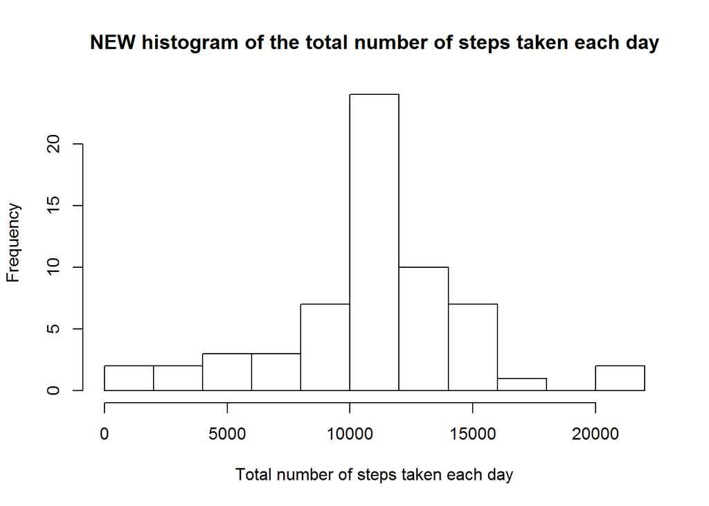

```r
hist(newsum, breaks = 10, main = "NEW histogram of the total number of steps taken each day", xlab = "Total number of steps taken each day")
```

By comparing this new histogram with the previous histogram, it is clear to see that the total number of steps taken each day is more normally distributed by replacing the `NA`s with the mean for that 5-minute interval.

```r
tapply(newac$steps, newac$date, mean)
```

```
## 2012-10-01 2012-10-02 2012-10-03 2012-10-04 2012-10-05 2012-10-06
## 37.3825996  0.4375000 39.4166667 42.0694444 46.1597222 53.5416667
## 2012-10-07 2012-10-08 2012-10-09 2012-10-10 2012-10-11 2012-10-12
## 38.2465278 37.3825996 44.4826389 34.3750000 35.7777778 60.3541667
## 2012-10-13 2012-10-14 2012-10-15 2012-10-16 2012-10-17 2012-10-18
## 43.1458333 52.4236111 35.2048611 52.3750000 46.7083333 34.9166667
## 2012-10-19 2012-10-20 2012-10-21 2012-10-22 2012-10-23 2012-10-24
## 41.0729167 36.0937500 30.6284722 46.7361111 30.9652778 29.0104167
## 2012-10-25 2012-10-26 2012-10-27 2012-10-28 2012-10-29 2012-10-30
##  8.6527778 23.5347222 35.1354167 39.7847222 17.4236111 34.0937500
## 2012-10-31 2012-11-01 2012-11-02 2012-11-03 2012-11-04 2012-11-05
## 53.5208333 37.3825996 36.8055556 36.7048611 37.3825996 36.2465278
## 2012-11-06 2012-11-07 2012-11-08 2012-11-09 2012-11-10 2012-11-11
## 28.9375000 44.7326389 11.1770833 37.3825996 37.3825996 43.7777778
## 2012-11-12 2012-11-13 2012-11-14 2012-11-15 2012-11-16 2012-11-17
## 37.3784722 25.4722222 37.3825996  0.1423611 18.8923611 49.7881944
## 2012-11-18 2012-11-19 2012-11-20 2012-11-21 2012-11-22 2012-11-23
## 52.4652778 30.6979167 15.5277778 44.3993056 70.9270833 73.5902778
## 2012-11-24 2012-11-25 2012-11-26 2012-11-27 2012-11-28 2012-11-29
## 50.2708333 41.0902778 38.7569444 47.3819444 35.3576389 24.4687500
## 2012-11-30
## 37.3825996
```

```r
tapply(newac$steps, newac$date, median)
```

```
## 2012-10-01 2012-10-02 2012-10-03 2012-10-04 2012-10-05 2012-10-06
##   34.11321    0.00000    0.00000    0.00000    0.00000    0.00000
## 2012-10-07 2012-10-08 2012-10-09 2012-10-10 2012-10-11 2012-10-12
##    0.00000   34.11321    0.00000    0.00000    0.00000    0.00000
## 2012-10-13 2012-10-14 2012-10-15 2012-10-16 2012-10-17 2012-10-18
##    0.00000    0.00000    0.00000    0.00000    0.00000    0.00000
## 2012-10-19 2012-10-20 2012-10-21 2012-10-22 2012-10-23 2012-10-24
##    0.00000    0.00000    0.00000    0.00000    0.00000    0.00000
## 2012-10-25 2012-10-26 2012-10-27 2012-10-28 2012-10-29 2012-10-30
##    0.00000    0.00000    0.00000    0.00000    0.00000    0.00000
## 2012-10-31 2012-11-01 2012-11-02 2012-11-03 2012-11-04 2012-11-05
##    0.00000   34.11321    0.00000    0.00000   34.11321    0.00000
## 2012-11-06 2012-11-07 2012-11-08 2012-11-09 2012-11-10 2012-11-11
##    0.00000    0.00000    0.00000   34.11321   34.11321    0.00000
## 2012-11-12 2012-11-13 2012-11-14 2012-11-15 2012-11-16 2012-11-17
##    0.00000    0.00000   34.11321    0.00000    0.00000    0.00000
## 2012-11-18 2012-11-19 2012-11-20 2012-11-21 2012-11-22 2012-11-23
##    0.00000    0.00000    0.00000    0.00000    0.00000    0.00000
## 2012-11-24 2012-11-25 2012-11-26 2012-11-27 2012-11-28 2012-11-29
##    0.00000    0.00000    0.00000    0.00000    0.00000    0.00000
## 2012-11-30
##   34.11321
```

## Are there differences in activity patterns between weekdays and weekends?

Identify which weekday each date is and save the result in the variable `whichday`.

```r
for (i in 1:nrow(newac)) {
      newac$whichday[i] <- weekdays(as.Date(newac$date[i]))
}
for (i in 1:nrow(newac)) {
      if (newac$whichday[i] == "Saturday" | newac$whichday[i] == "Sunday") {
            newac$whichday[i] <- "weekend"
      } else {
            newac$whichday[i] <- "weekday"
      }
}
```

Subset the new dataset into two sets: `wdays` and `wends`.

```r
wdays <- newac[newac$whichday == "weekday", ]
wends <- newac[newac$whichday == "weekend", ]
```

Construct the plots:

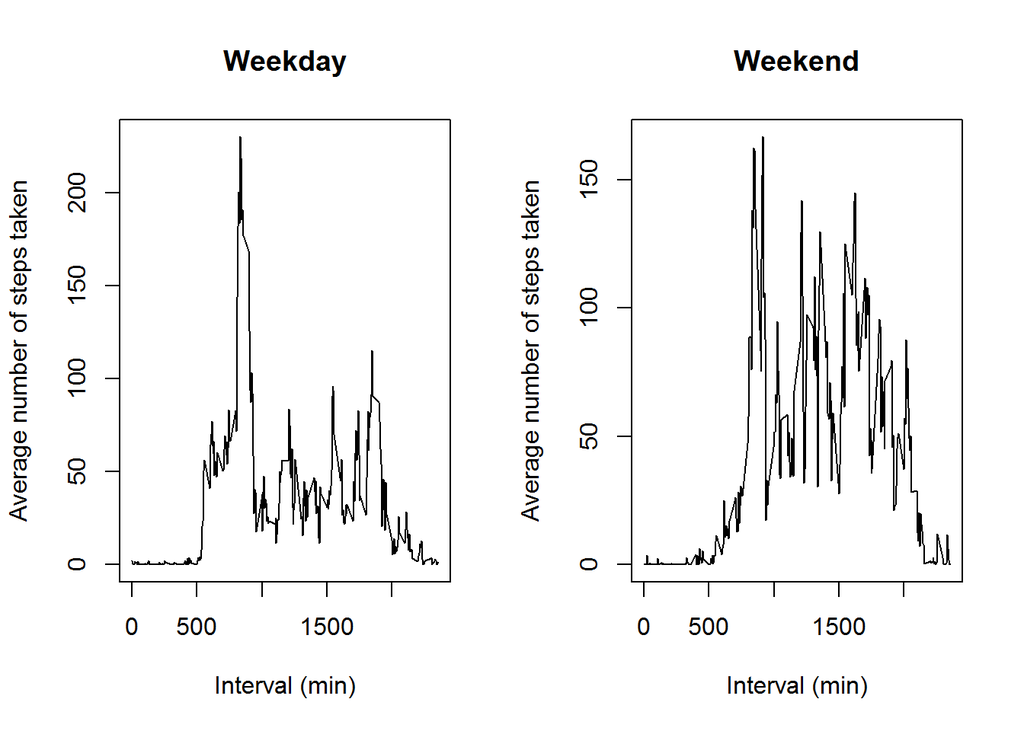

```r
par(mfrow = c(1, 2))
wdmean <- tapply(wdays$steps, wdays$interval, mean)
plot(unlist(dimnames(wdmean)), wdmean, type = "l", xlab = "Interval (min)", ylab = "Average number of steps taken", main = "Weekday")
wemean <- tapply(wends$steps, wends$interval, mean)
plot(unlist(dimnames(wemean)), wemean, type = "l", xlab = "Interval (min)", ylab = "Average number of steps taken", main = "Weekend")
```